# Technology, Quality of Life, and Relationships

### **Introduction**

Our dataset is compiled of categorical data received through telephone interviews in the USA in 2013. The dataset was originally used for a study on online dating; however through investigation of the variables, insight can be generated on the quality of life for a sample of Americans.

With our core research topic focusing on the sample’s quality of life, the data offers two sections of analysis: firstly through relationships and secondly through Home Economics.

The following slides will provide an overview of the dataset.

#### **Decriptive Statistics (part 1)**

As seen from below, the respondents were predominantly white, slightly older (median age of 53).

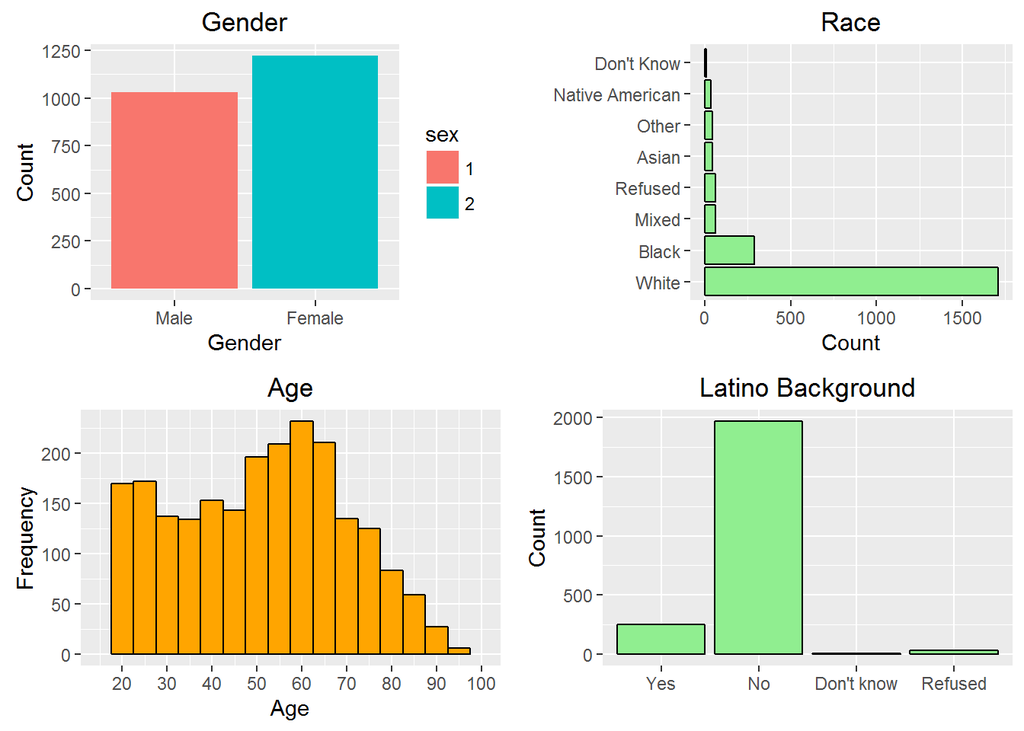

#### **Decriptive Statistics (part 2)**

The respondents are well educated, with 42% employed full time; however, the number of retirees is also large (27% of all respondents). The majority live in a 2-person household. It is noteworthy to point out that 299 people (13%) refused to disclose their family income level. The second most heard response (also 13%) was earnings of 50-75 thousand USD per year.

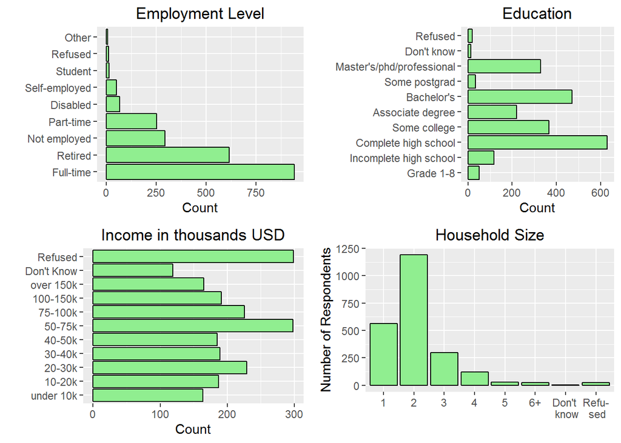

#### **Decriptive Statistics (part 3)**

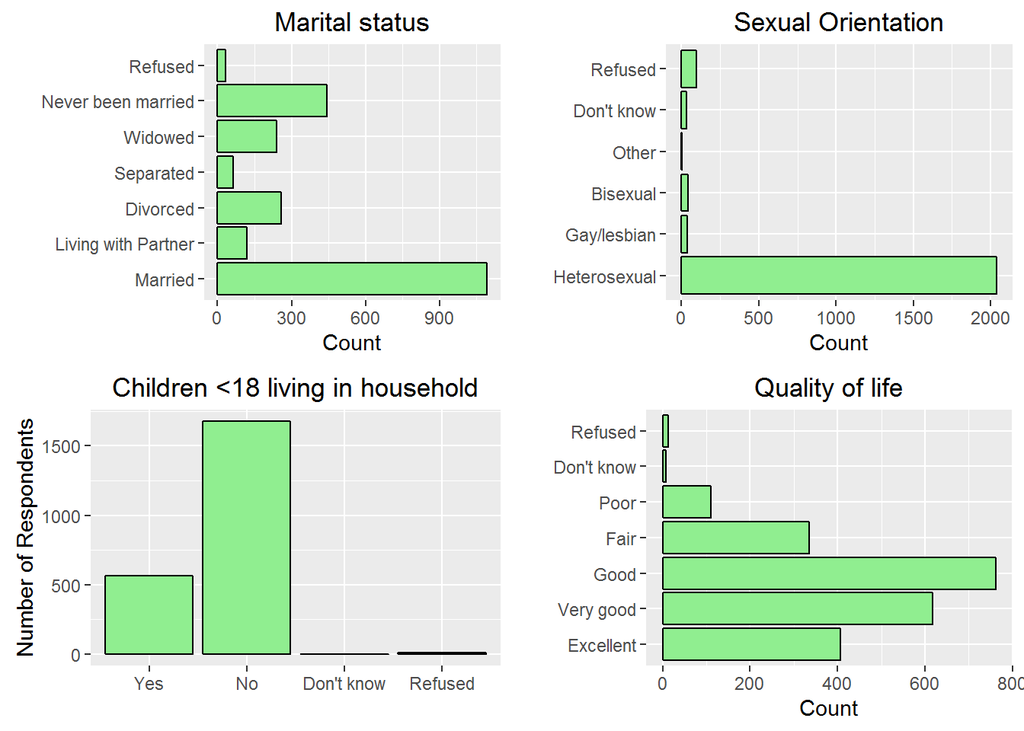

### **Relationships & Quality of Life**

Within our project, we observed that online dating is a focus of many of the questions. As the objective of our analysis is one of a modern perception of quality of life, and online dating is such a novel phenomenon, we believe it fitting to explore how relationships affect quality of life with a certain focus on online dating.

On the graphs below, we explored the relationship between:

- The search for a romantic partner and having an online dating profile, and
- The perception of how difficult it is to meet a partner and an online dating profile

Limitation 1: while there were a total of 138 people in our sample looking for a partner, only 51 answered the question on whether they have an online dating profile. The situation was similar for people that weren’t looking for a partner. Thus, the following graphs only contain responses for people that answered both questions.

Limitation 2: while there were a total of 134 people in our sample who answered the question on how easy/difficult it is to meet people, only 50 answered the question on whether they have an online dating profile.

- According to the left-most graph, of 51 people looking for a romantic partner, 33 had an active online dating profile, whereas, 18 individuals did not.
- On the right-most graph, of 50 respondents, 58% felt it was difficult to meet people in the city or town where they lived. Of this subsample, 62% had a currently posted online profile. This is however a small and specific subsection of the greater interviewed sample, so other related questions with greater response rates will be investigated.

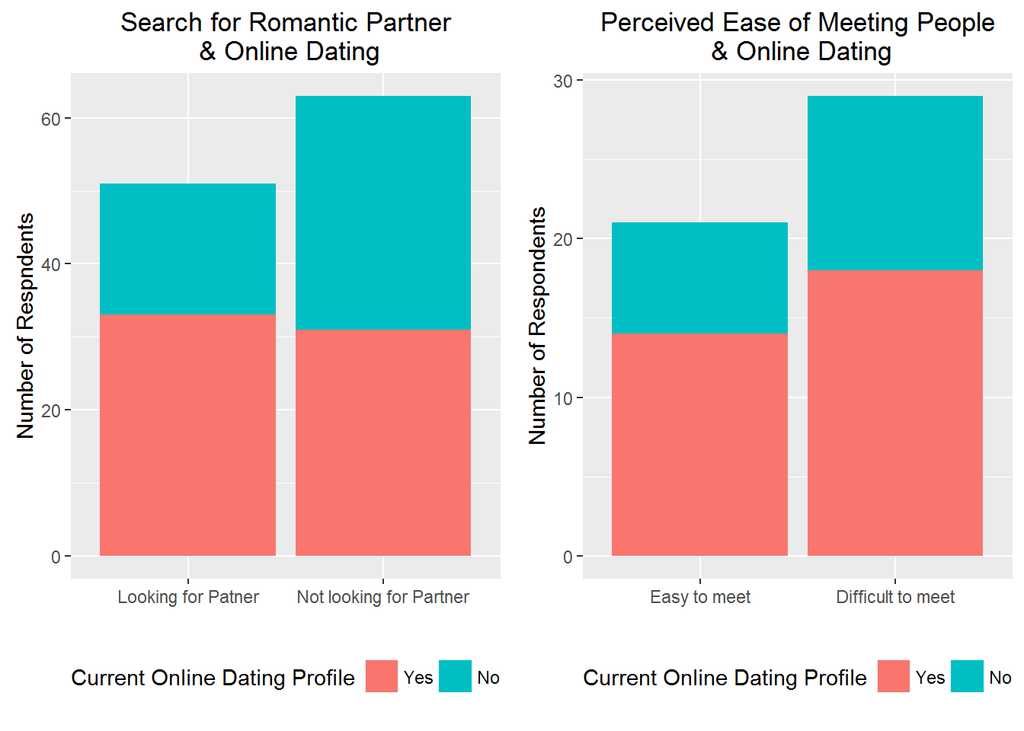

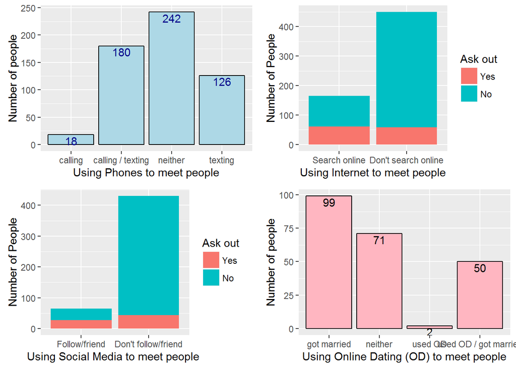

Four ideas – what proportion of people that have used phone, internet, social media or online dating to meet people.

#### **Origin of the Relationship vs Quality of Life**

Based on the graph below, it may seem that the origine of the relationship (whether a person met their partner online or offline) has some association to people’s quality of life. For example:

- 35% of people that met offline said their quality of life was good. Meanwhile, only 27% of people that met online believed the same.
- 20% of people that met offline said their quality of life was excellent. Meanwhile, 27% of people that met online believed the same.

However, running the chi squre test does not support the claim that the two distributions are different (p value is high).

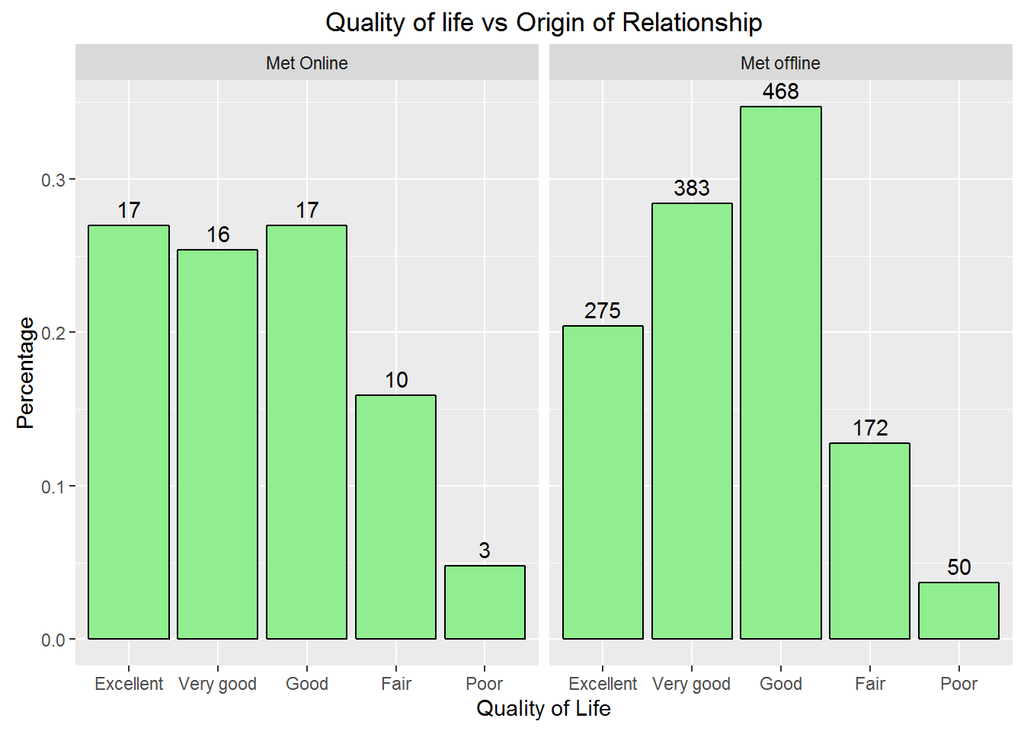

```
##
##  Pearson's Chi-squared test
##
## data:  ex[, "met"] and ex[, "hap"]
## X-squared = 3.1313, df = 4, p-value = 0.5361
```

#### **Privacy & Conflict in a Relationship**

We can use logistic regression to find the impact of having a common email account, a shared social networking profile, a shared online calendar, and shared online passwords on conflicts in relationships.

```
##
## Call:
## glm(formula = rel6 ~ rel4a + rel4b + rel4c + rel5, family = binomial,
##     data = train)
##
## Deviance Residuals:
##     Min       1Q   Median       3Q      Max
## -1.5309  -1.4110   0.9563   0.9605   1.1423
##
## Coefficients:
##             Estimate Std. Error z value Pr(>|z|)
## (Intercept)  0.13308    1.43454   0.093    0.926
## rel4a        0.07765    0.38907   0.200    0.842
## rel4b        0.37337    0.71742   0.520    0.603
## rel4c       -0.25588    0.26831  -0.954    0.340
## rel5         0.01090    0.23319   0.047    0.963
##
## (Dispersion parameter for binomial family taken to be 1)
##
##     Null deviance: 247.16  on 187  degrees of freedom
## Residual deviance: 245.91  on 183  degrees of freedom
##   (41 observations deleted due to missingness)
## AIC: 255.91
##
## Number of Fisher Scoring iterations: 4
```

### **Quality of Life and Household Economics**

The second aspect of this study focuses on how household economics, specifically – family structure, education, income and available technology – relates to the respondent’s quality of life

#### **Quality of Life vs presence of children in the household**

Looking at the graph below, it appears that households without children are less likely to say that their quality of life is Excellent. However, using the chi square test, we see that the p-value is high, indicating that there is not enough evidence to conclude that there are differences in quality of life among people with and without children <18 in the household.

Note: This dataset exludes 32 respondents who answered “Don’t Know” or “Refuse” to either the question on the quality of life or the question on whether they have children under 18 in the household.

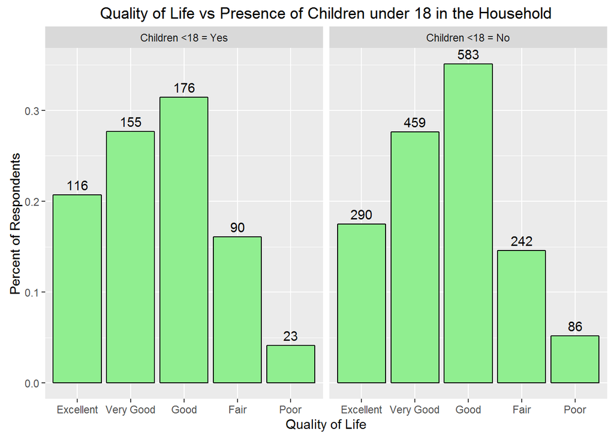

```
##
##  Pearson's Chi-squared test
##
## data:  quality_vs_children[, "par"] and quality_vs_children[, "q1"]
## X-squared = 5.6868, df = 4, p-value = 0.2238
```

#### **Quality of Life vs Use of Cell Phones**

Looking at the graph below, it appears that respondents that use cellphones are more likely to say that their quality of life is Excellent. Using the chi square test, we see that the p-value is low, indicating that there is evidence to conclude that there are differences in the quality of life levels among people that use internet on the phone and those that don’t.

This dataset exludes 22 respondents who answered “Don’t Know” or “Refuse” to either the question on the quality of life or the question on whether they use internet on their cellphone.

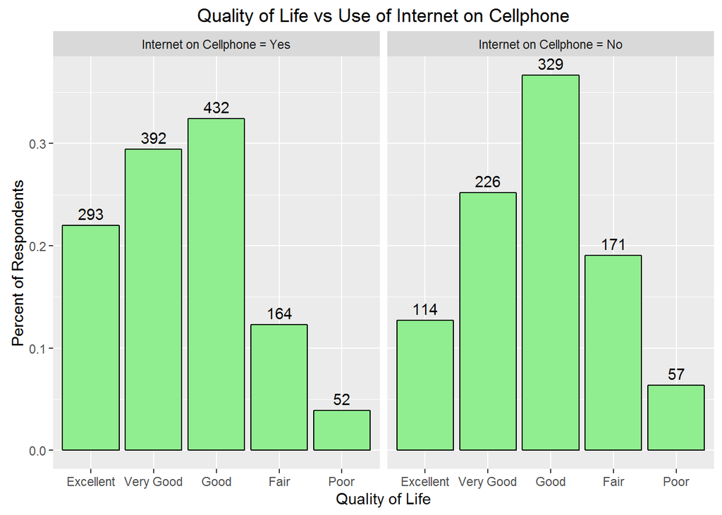

```
##
##  Pearson's Chi-squared test
##
## data:  quality_vs_phoneNet[, "intmob"] and quality_vs_phoneNet[, "q1"]
## X-squared = 54.468, df = 4, p-value = 4.2e-11
```

#### **Quality of Life vs Use of Social Networks**

Looking at the graph below, the users and non-users of social networks (Facebook, Twitter, LinkedIn, etc) appear to report their quality of life levels similarly. Using the chi square test, we see that the p-value is high, indicating that there is no evidence to conclude that there are differences in the quality of life levels between users and non-users of social networks.

Note: This dataset exludes 371 respondents who answered “Don’t Know” or “Refuse” to either the question on the quality of life or the question on the use of social networks. Respondents who do not use internet were also exlcluded.

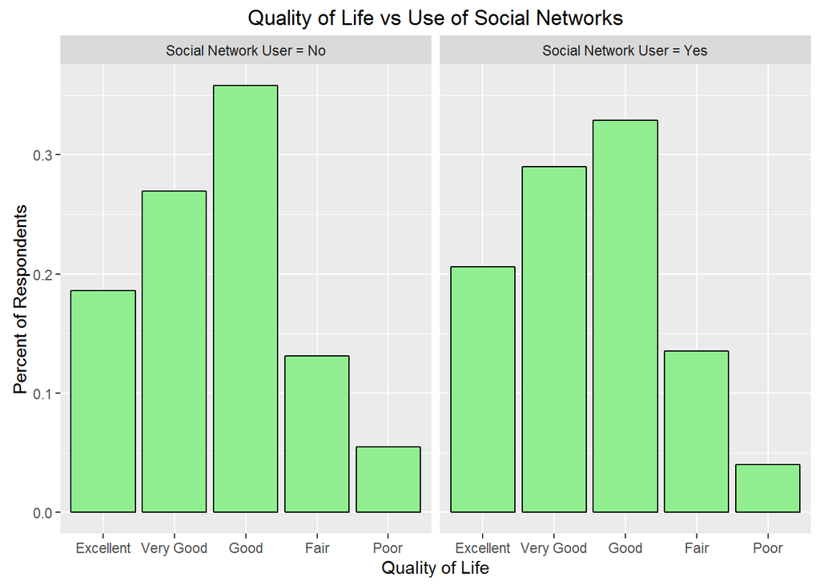

```
##
##  Pearson's Chi-squared test
##
## data:  quality_vs_socNetworks[, "SN_user"] and quality_vs_socNetworks[, "q1"]
## X-squared = 4.3184, df = 4, p-value = 0.3646
```

#### **Income vs Smart Phone Use**

The following graph demonstrates the relationship between type of smartphone used and income. Visually, it appears that the prevalence of the iPhone is associated with higher income level.

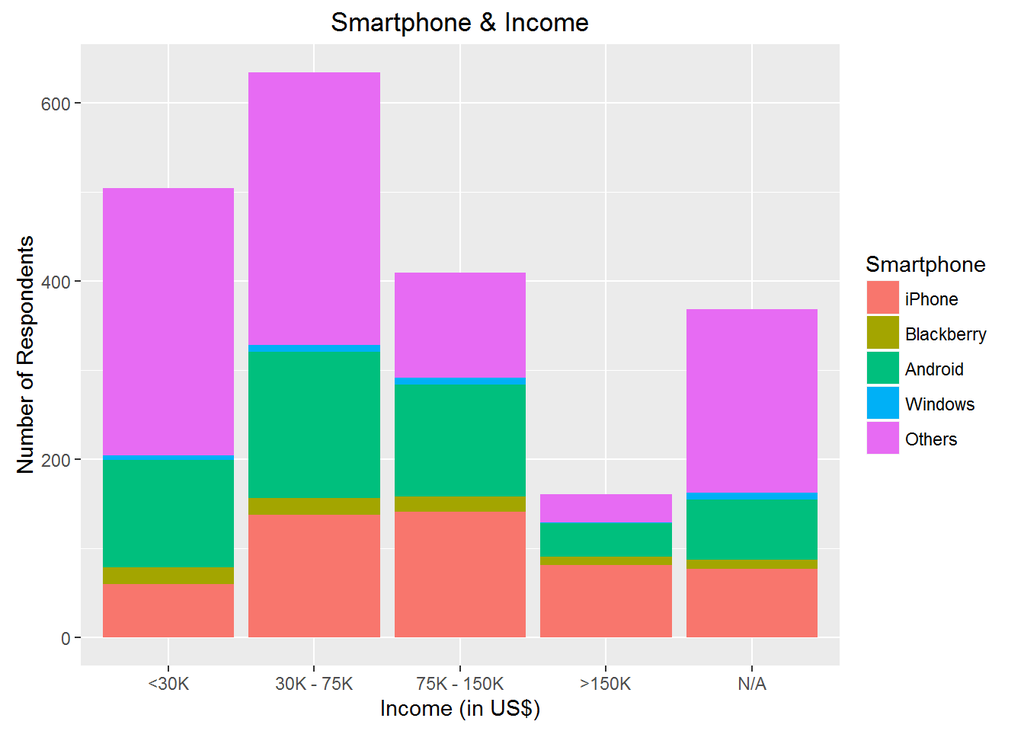

#### **Income vs Education**

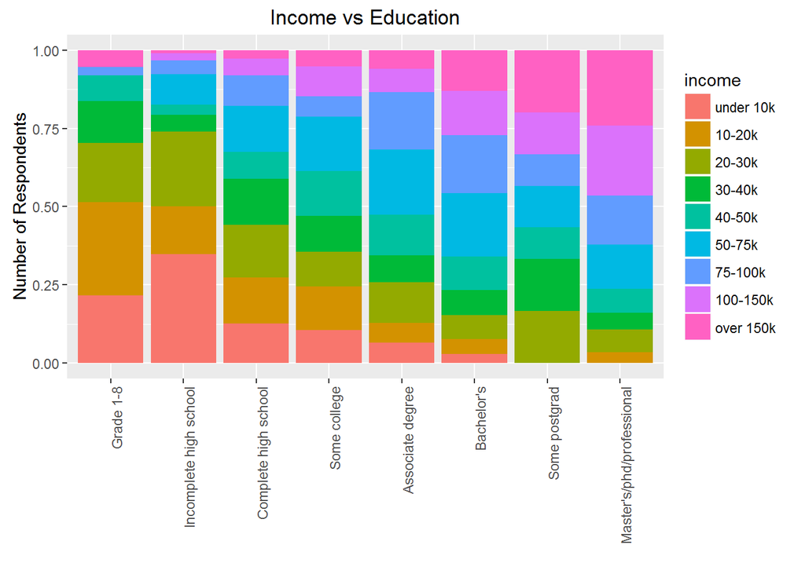

### **Limitations**

While the population size was composed of 2252 respondents, due to significant clustering of respondents into groups (internet users, mobile internet users, social network users, etc), the number of responds upon whom analysis of online dating behaviour could be completed was very small.

- There are only 198 people in the sample that used online dating sites
- Only 57 people have used a dating app on their phone

As a result, limited amout of research could be done specifically on online dating behavior and how it affects quality of life.

To study this phenomena at greater depth, a recommendaiton for the future analysis would be to collect data solely from online dating service users.

The fact that the dataset contained no continuous variables, limited the type of analysis and modelling that could be completed.